# Critical x Meta

Author

Ambra Perugini

Published

October 13, 2025

# What and Why?

I am trying to apply critical effect size values to meta-analysis and mini-meta. The goal is to demonstrate the utility of critical effect size values in practice and also evaluate with some examples what is going on in social psychology.

The smallest detectable effect that can reach statistical significance given a specific sample size, alpha level, and test statistic.

Basically converting the critical t into a critical Cohen’s d for example.

# Meta-analysis

We want to have different scenarios:

- one with small sample size for individual studies
- one with large sample size for individual studies

## Talamini et al. (2017)

We have decided to use the meta-analysis by Talamini et al. (2017) as an example of small samples.

It has:

- long term memory,
- short term memory
- working memory

We will compute critical values both for one tailed and two tailed t-test, assuming alpha at the .05 threshold and plot the two tailed t-test for now.

## Long Term Memory

Let’s plot critical values (for a two tailed test) next to the actual effect sizes.

We compared the estimated meta-analytic effect size to the critical values of individual studies. In 0% of cases, the critical value was lower than the meta-analytic effect size, indicating that these studies would have been able to detect a statistically significant effect of that magnitude. When comparing the critical values to the bias corrected meta-analytic effect size the percentage was still 0%, as it couldn’t go any lower.

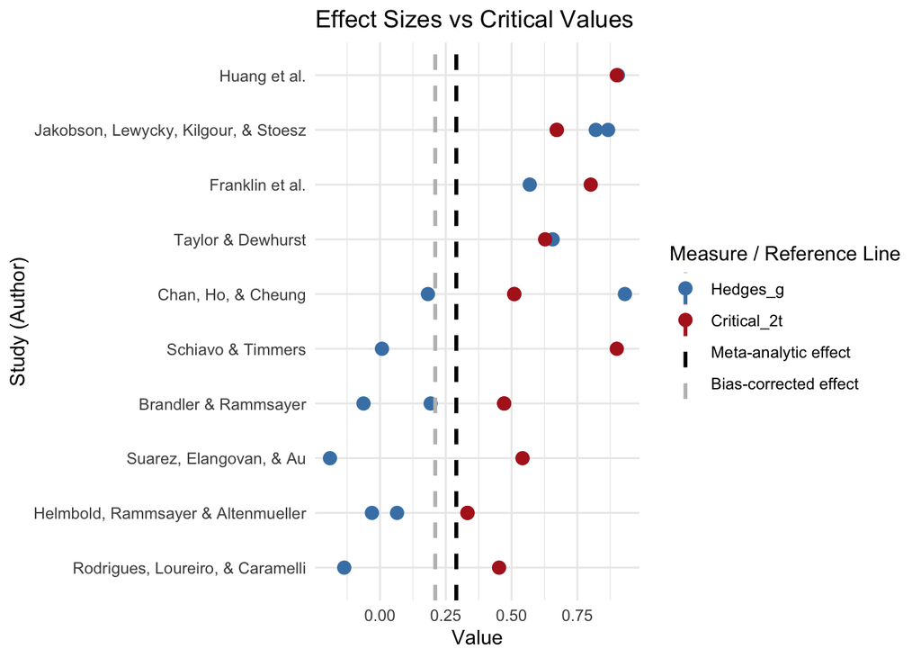

## Short Term Memory

Let’s plot critical values (for a two tailed test) next to the actual effect sizes. We compared the estimated meta-analytic effect size to the critical values of individual studies. In 30% of cases, the critical value was lower than the meta-analytic effect size, indicating that these studies would have been able to detect a statistically significant effect of that magnitude. When comparing the critical values to the bias corrected meta-analytic effect size the percentage lowered to 0%.

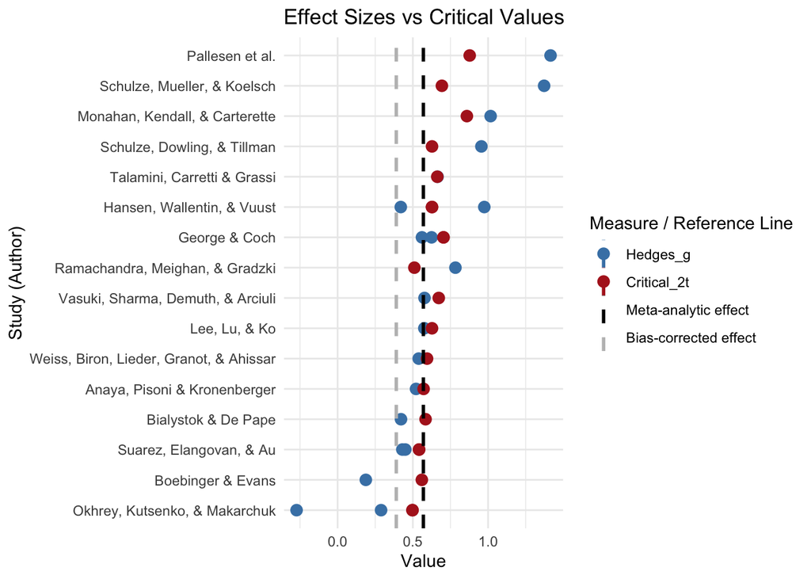

## Working Memory

Let’s plot critical values (for a two tailed test) next to the actual effect sizes. We compared the estimated meta-analytic effect size to the critical values of individual studies. In 15.79% of cases, the critical value was lower than the meta-analytic effect size, indicating that these studies would have been able to detect a statistically significant effect of that magnitude.

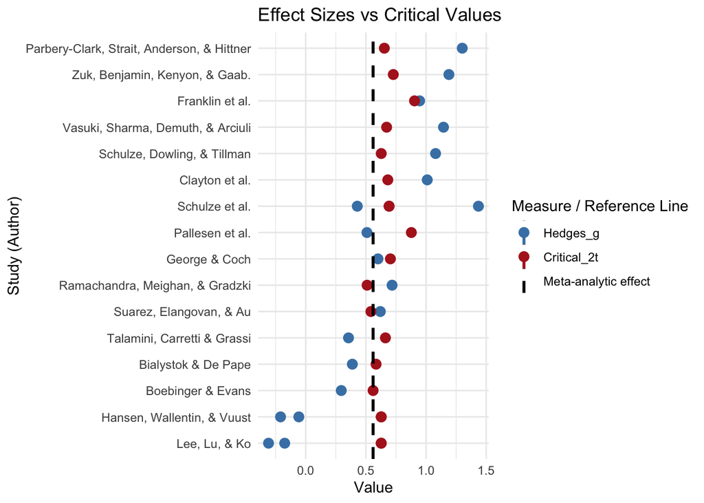

```
          estimate        se      zval       pval      ci.lb    ci.ub
intrcpt -0.7716675 0.7201839 -1.071487 0.28395061 -2.1832021 0.639867
SE       4.1386218 2.2058217  1.876227 0.06062414 -0.1847092 8.461953
```

```
          estimate        se       zval       pval       ci.lb      ci.ub
intrcpt -0.1088899 0.3648861 -0.2984216 0.76538139 -0.82405358  0.6062738
I(SE^2)  6.2973200 3.2558538  1.9341532 0.05309429 -0.08403615 12.6786760
```

## Harkin et al. (2016)

## Miller et al. (2015)

## Adesope et al. (2010)

## Shannon et al. (2022)

This case is a good example of all studies having critical effect size values lower than the meta-analytic effect (100%) meaning that even the individual studies where suited to find a significant effect if there was one as in this case, it is also probably due to the nature of the research field of online data collection that makes it easier to have bigger samples.

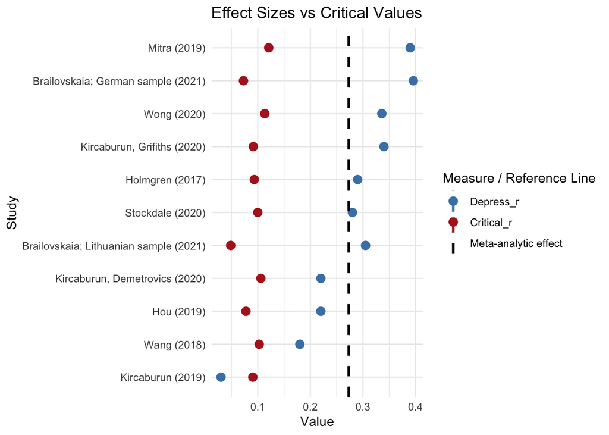

## Mini meta

We also want to use a mini meta, and for this purpose we are using as a toy example the one by Tuk et al. (2015). They were investigating, in a total of 18 studies, self-control tasks (inhibitory spillover). The amount of times in which the single study had a critical value smaller than the meta-analytic effect was 0%, meaning that each single study didn’t reach even 50% power for the meta-analytic effect.

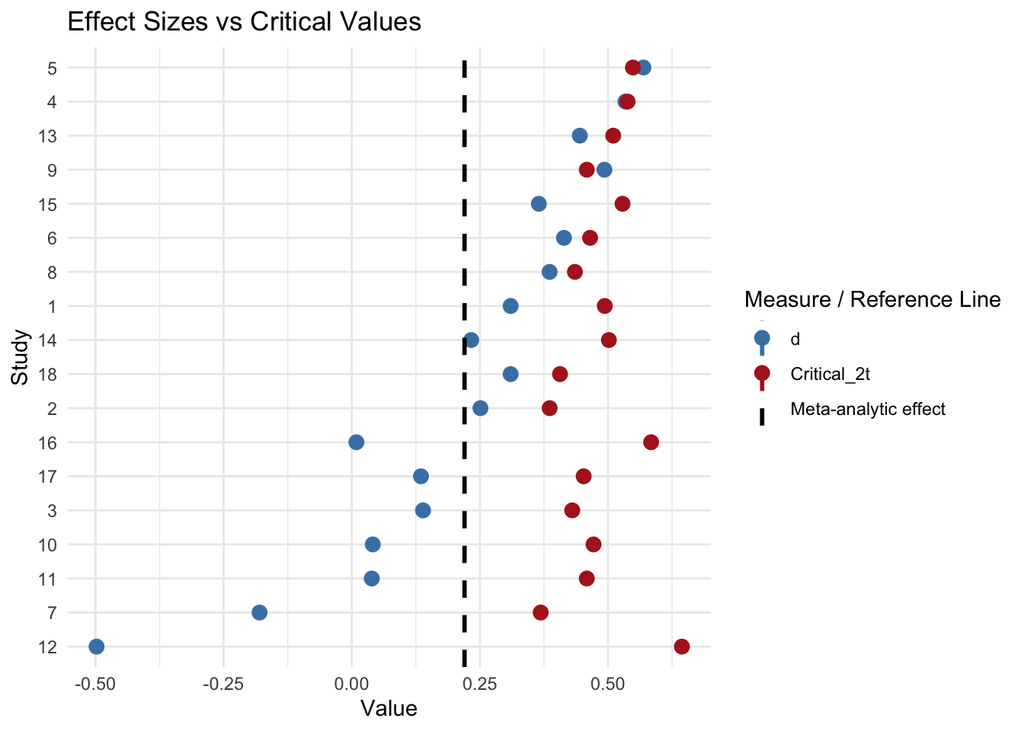

# Who cited the metas did implement knowledge into sample size?

## Talamini et al. (2017)

For now I have downloaded 133 out of 215 citations.

Min (2025) -> 400 (200 x group, independent t-tests) no power analysis or sample size formalized justification

Jakubowski et al. (2025) -> unrelated research question

Cara (2024) -> 70 (35 x group) ANCOVA, no power analysis or sample size justification

Price-Mohr & Price (2021) -> 15 intervention and 17 control ANCOVA, found significant effect of intervention 4h music training, no power or sample size justification

Byczynski et al. (2022) -> 16 children (8 x group), EEG study, no sample size justification, independent sample t-test

Gray et al. (2025) -> 75 and 55 x group, no planned sample size because they had access to a court study, crazy amount of variables including cognitive ones

Jakubowski et al. (2025) -> 304 subjects, unrelated measures, no justification

## References

Adesope, O. O., Lavin, T., Thompson, T., & Ungerleider, C. (2010). A systematic review and meta-analysis of the cognitive correlates of bilingualism. *Review of Educational Research*, *80*(2), 207–245.

Byczynski, G., Schibli, K., Goldfield, G., Leisman, G., & D’Angiulli, A. (2022). EEG power band asymmetries in children with and without classical ensemble music training. *Symmetry*, *14*(3). https://doi.org/10.3390/sym14030538

Cara, M. A. (2024). The influence of music reading on spatial working memory and self-assessment accuracy. *Brain Sciences*, *14*(11), 1152.

Chu, T. H., Sun, M., & Crystal Jiang, L. (2023). Self-disclosure in social media and psychological well-being: A meta-analysis. *Journal of Social and Personal Relationships*, *40*(2), 576–599.

Gray, R., Craig, M., Falk Erhag, H., Skoog, I., & Gow, A. J. (2025). Assessing the effect of musical experience on cognitive function in older age: A coordinated analysis. *Aging, Neuropsychology, and Cognition*, 1–24.

Harkin, B., Webb, T. L., Chang, B. P., Prestwich, A., Conner, M., Kellar, I., Benn, Y., & Sheeran, P. (2016). Does monitoring goal progress promote goal attainment? A meta-analysis of the experimental evidence. *Psychological Bulletin*, *142*(2), 198.

Jakubowski, K., Lee, E., Bai, E., & Belfi, A. M. (2025). Individual differences in music-evoked autobiographical memories. *Musicae Scientiae*, *29*(2), 195–216.

Miller, D. J., Spengler, E. S., & Spengler, P. M. (2015). A meta-analysis of confidence and judgment accuracy in clinical decision making. *Journal of Counseling Psychology*, *62*(4), 553.

Min, X. (2025). The effect of amateur piano playing on memory performance: A focus on chinese piano players. *Cognitive Development*, *73*, 101539.

Price-Mohr, R., & Price, C. (2021). Learning to play the piano whilst reading music: Short-term school-based piano instruction improves memory and word recognition in children. *International Journal of Early Childhood*, *53*(3), 333–344.

Shannon, H., Bush, K., Villeneuve, P. J., Hellemans, K. G., Guimond, S., et al. (2022). Problematic social media use in adolescents and young adults: Systematic review and meta-analysis. *JMIR Mental Health*, *9*(4), e33450.

Talamini, F., Altoè, G., Carretti, B., & Grassi, M. (2017). Musicians have better memory than nonmusicians: A meta-analysis. *PloS One*, *12*(10), e0186773.

Tuk, M. A., Zhang, K., & Sweldens, S. (2015). The propagation of self-control: Self-control in one domain simultaneously improves self-control in other domains. *Journal of Experimental Psychology: General*, *144*(3), 639.